# Projet Final

Christophe tiet

21 décembre 2018

Initialisation du répertoire de travail

```r
setwd("C:/Users/Chris/Desktop/Prepa_M2/Initiation R")
```

# 2 Préparation des données

## 2.2 Importation et mise en forme ( 2pts)

Importation des deux fichiers .csv

```r
urgence=read.csv("urgence.csv",header=TRUE,sep=";")
meteo=read.csv("meteo.csv",header=TRUE,sep=";")
```

Renommage des variables A_6, A_5, A_4, A_3, A_2, A_1 et A

```r
colnames(urgence)=c("MMJJ","2003","2004","2005","2006","2007","2008","2009")
```

Formatage de la variable MMJJ afin qu’elle contienne 4 chiffres

```r
urgence$MMJJ=sprintf("%04d",urgence$MMJJ)
```

Création d’un dataframe urgence2 qui sera le dataframe urgence transformé dans le format demandé

```r
urgence2=data.frame(annee=integer(),mois=integer(),jour=integer(),entree=integer())
```

Création d’une boucle for qui va extraire les données d’urgence et les placer dans non nouveau dataframe urgence2

```r
for (j in seq(2,ncol(urgence))) {

  for (i in seq(nrow(urgence))) {

    urgence2[i+366*(j-2),"annee"]=as.integer(colnames(urgence[j]))
    urgence2[i+366*(j-2),"mois"]=as.integer(substr(urgence[i,"MMJJ"],1,2))
    urgence2[i+366*(j-2),"jour"]=as.integer(substr(urgence[i,"MMJJ"],3,4))
    urgence2[i+366*(j-2),"entree"]=urgence[i,j]
    }
}
```

Suppression des dates postérieures au 31/10/2009 dans le dataframe urgence2 et meteo après avoir cherché les indices des lignes avec la fonction tail()

```r
urgence2=urgence2[-c(seq(2501,2562)),]
meteo=meteo[-c(seq(2497,2504)),]
```

Suppression des 29 Févriers 2003, 2005, 2006 et 2007, on sait que le 29 Février est situé à chaque n*366

```r
urgence2=urgence2[-c(366,1098,1464,1830),]
```

Renommage des variables de météo et rajout de la variable date_j

```r
colnames(meteo)=c("annee","mois","jour","precip","temp")
meteo$date_j=as.Date(paste(urgence2$jour,urgence2$mois,urgence2$annee,sep="/"),format="%d/%m/%Y")
```

Fusion des deux dataframes urgence2 et meteo en dataframe projet

```r
projet=merge(meteo,urgence2,by=c("annee","mois","jour"))
```

Tri en fonction de la date_j

```r
projet=projet[order(projet$"date_j"),]
```

Redéfinition de l’index des observations de 1 à 2496 dans l’ordre trié par date

```r
rownames(projet)=seq(1,nrow(projet))
```

Vérification afin de voir que le str(projet) corresponde bien à celui demandé dans l’énoncé

```r
str(projet)
```

```
## 'data.frame':    2496 obs. of  7 variables:
##  $ annee : int  2003 2003 2003 2003 2003 2003 2003 2003 2003 2003 ...
##  $ mois  : int  1 1 1 1 1 1 1 1 1 1 ...
##  $ jour  : int  1 2 3 4 5 6 7 8 9 10 ...
##  $ precip: num  3.4 0.8 0.2 2.4 0.6 1.2 1.2 3.4 0 0 ...
##  $ temp  : num  7.2 10.9 11 6.1 2 0.6 -0.9 4.3 5.4 -0.9 ...
##  $ date_j: Date, format: "2003-01-01" "2003-01-02" ...
##  $ entree: int  145 127 132 120 147 106 111 105 119 95 ...
```

## 2.3 Traitement des valeurs manquantes (2 pts)

Recherche valeur manquante dans precip et dans temp grâce à la fonction which() et is.na()

```r
projet[which(is.na(projet$precip)),]
```

```
##     annee mois jour precip temp     date_j entree
## 599  2004    8   20     NA 19.9 2004-08-21    136
## 655  2004   10   15     NA 11.6 2004-10-16    117
## 656  2004   10   16     NA  9.6 2004-10-17    145
```

```r
projet[which(is.na(projet$temp)),]
```

```
##      annee mois jour precip temp     date_j entree
## 1304  2006    7   27     19   NA 2006-07-27    139
## 1305  2006    7   28      0   NA 2006-07-28    141
```

Etant donné qu’il n’y a que 5 valeurs manquantes, il me semble plus cohérent d’aller chercher à les compléter en trouvant la valeur sur des sites extérieurs (meteo-climat-bzh.dyndns.org et infoclimat.fr).

Remplacement des valeurs manquantes

```r
projet[599,"precip"]=0.0
projet[655,"precip"]=6.6
projet[656,"precip"]=23.4
projet[1304,"temp"]=26.8
projet[1305,"temp"]=22.8
```

## 2.4 Création de variables (2 pts)

Ajout de la variable jour_semaine grace à la fonction weekdays.Date

```r
projet$jour_semaine=weekdays.Date(projet$date_j)
```

Formatage de la variable jour en valeur à 2 chiffres

```r
projet$jour=sprintf("%02d",projet$jour)
```

Création de la variable saison grâce à une boucle for en fonction de la valeur date qui est la concaténation du mois et du jour. A titre d’exemple, on considère ainsi que la saison “printemps” correspond à une valeur mois+jour entre 320 et 620.

```r
for (i in seq(1,nrow(projet))) {
  date=as.numeric(paste0(projet$mois[i],projet$jour[i]))
  if (date>=320 & date<=620) {
    projet$saison[i]="printemps"
  } else if (date>=621 & date<=920) {
    projet$saison[i]="ete"
  } else if (date>=921 & date<=1220) {
    projet$saison[i]="automne"
  } else {
    projet$saison[i]="hiver"
  }
}
```

Reconversion de la variable jour en int qui a été converti en char lors du formatage en valeur à 2 chiffres

```r
projet$jour=as.integer(projet$jour)
```

# 3 Analyse descriptives

## 3.1 Etude de la variable entree ( 2pts)

Date de la valeur max entrée: **22/6/2008** avec 239 entrées

```r
projet[which(projet$entree==max(projet$entree,na.rm=TRUE)),]
```

```
##      annee mois jour precip temp     date_j entree jour_semaine saison
## 2001  2008    6   22      0 25.5 2008-06-23    239        lundi    ete
```

Création d’une boite à moustache

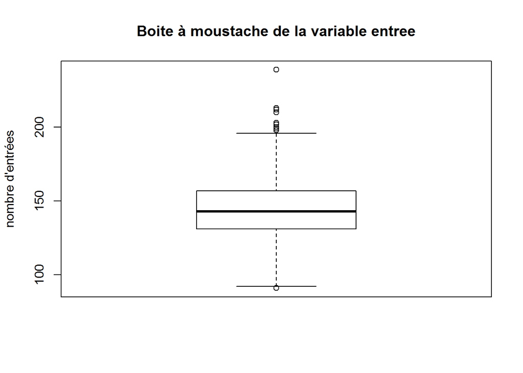

```r
boxplot(projet$entree,ylab="nombre d'entrées",main="Boite à moustache de la variable entree")
```

```r
summary(projet$entree)
```

```
##    Min. 1st Qu.  Median    Mean 3rd Qu.    Max.    NA's
##    91.0   131.0   143.0   144.4   157.0   239.0       5
```

Je vais maintenant chercher les valeurs au dessus de la moustache supérieure, c’est à dire les valeurs > (Q3+1.5(Q3-Q1)).

Grâce à la fonction summary(), nous savons que Q1=131 et Q3=157, on cherche donc les valeurs **>196**.

```r
projet[projet$entree>196,]
```

```
##      annee mois jour precip temp     date_j entree jour_semaine    saison
## 173   2003    6   22    0.0 28.3 2003-06-22    213     dimanche       ete
## 1269  2006    6   22    0.0 19.8 2006-06-22    198        jeudi       ete
## 1580  2007    4   29   26.0 16.9 2007-04-29    212     dimanche printemps
## 1629  2007    6   17    0.0 21.0 2007-06-17    198     dimanche printemps
## 1634  2007    6   22    0.0 18.5 2007-06-22    203     vendredi       ete
## 1678  2007    8    5    0.2 26.2 2007-08-05    199     dimanche       ete
## 2001  2008    6   22    0.0 25.5 2008-06-23    239        lundi       ete
## 2092  2008    9   21    0.0 17.6 2008-09-22    198        lundi   automne
## 2134  2008   11    2    5.4  9.0 2008-11-03    203        lundi   automne
## 2162  2008   11   30    1.0  5.0 2008-12-01    199        lundi   automne
## 2168  2008   12    6    0.8  9.8 2008-12-07    210     dimanche   automne
## 2231  2009    2    8    0.8  4.4 2009-02-08    202     dimanche     hiver
## 2343  2009    5   31    0.2 20.3 2009-05-31    210     dimanche printemps
## 2364  2009    6   21    0.0 17.8 2009-06-21    200     dimanche       ete
## 2462  2009    9   27    8.8 19.2 2009-09-27    203     dimanche   automne
## 2476  2009   10   11    0.4 18.5 2009-10-11    203     dimanche   automne
## 2490  2009   10   25    0.8 16.6 2009-10-25    198     dimanche   automne
## NA      NA   NA   NA     NA   NA       <NA>     NA         <NA>      <NA>
## NA.1    NA   NA   NA     NA   NA       <NA>     NA         <NA>      <NA>
## NA.2    NA   NA   NA     NA   NA       <NA>     NA         <NA>      <NA>
## NA.3    NA   NA   NA     NA   NA       <NA>     NA         <NA>      <NA>
## NA.4    NA   NA   NA     NA   NA       <NA>     NA         <NA>      <NA>
```

On remarque que les valeurs extrêmes se situent surtout le **dimanche** et le **22 Juin**.  
Les cabinets de medecins sont fermés le dimanche, il n’est pas étonnant de voir un nombre d’entrées plus élevées au niveau des urgences. Concernant la date du 22 Juin, elle pourrait être en relation avec la fête de la musique se déroulant le 21 Juin.

Afin de vérifier si la distribution de cette variable est gaussienne, j’utilise le test de Shapiro-Wilk.

```r
shapiro.test(projet$entree)
```

```
##
##  Shapiro-Wilk normality test
##
## data:  projet$entree
## W = 0.99326, p-value = 2.572e-09
```

La valeur de p étant inférieur à 0.05, on rejettera l’hypothèse nulle et on ne peut donc pas considérer que la distribution de la variable entree est gaussienne.

La valeur du quantile d’ordre 0.95 est de **176.5**.

```r
quantile(projet$entree,prob=0.95,na.rm=TRUE)
```

```
##   95%
## 176.5
```

Création d’un vecteur overquantile95 qui stockera les débuts des périodes où le nombre d’entree est supérieur à 176.5 pendant deux jours consécutifs.

```r
overquantile95=c()
```

Mise en place d’une boucle for afin de trouver les périodes où le nombre d’entree est supérieur à 176.5 pendant deux jours consécutifs. Et affichage du résultat.

```r
for(i in seq(1,nrow(projet)-5)) {
  if (projet$entree[i]>176.5 & projet$entree[i+1]>176.5) {
    overquantile95=append(overquantile95,projet$date_j[i])
    }
}
length(overquantile95)
```

```
## [1] 21
```

```r
overquantile95
```

```
##  [1] "2003-09-21" "2006-06-18" "2007-02-03" "2007-04-21" "2007-04-28"
##  [6] "2007-05-12" "2008-04-27" "2008-05-12" "2008-05-13" "2008-06-01"
## [11] "2008-06-23" "2008-09-22" "2008-10-19" "2008-11-02" "2009-05-16"
## [16] "2009-05-23" "2009-05-24" "2009-05-31" "2009-06-06" "2009-06-07"
## [21] "2009-06-21"
```

Le vecteur compte 21 valeurs mais il y a 3 périodes de 3 jours consécutifs. Cela fait donc un total de **18 périodes** pour lesquelles on observe plus de 2 jours consécutifs avec des valeurs suprieures aux quantiles d’ordre 0.95(176.5).

Représentation de la série temporelle du nombre d’entrée.

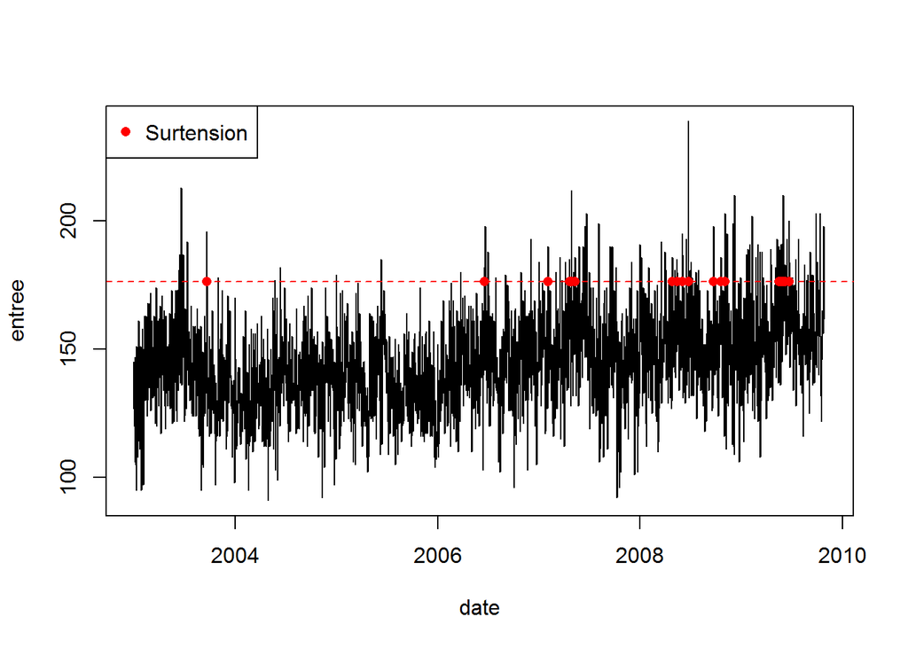

```r
plot(projet$date_j,projet$entree,type="l",xlab="date",ylab="entree")
abline(h=176.5, col="red",lty=2)
legend("topleft",legend="Surtension",pch=16,col="red")
points(x=overquantile95,y=rep(176.5,length(overquantile95)),pch=16,col="red")
```

## 3.2 Nuage de points (1 pt)

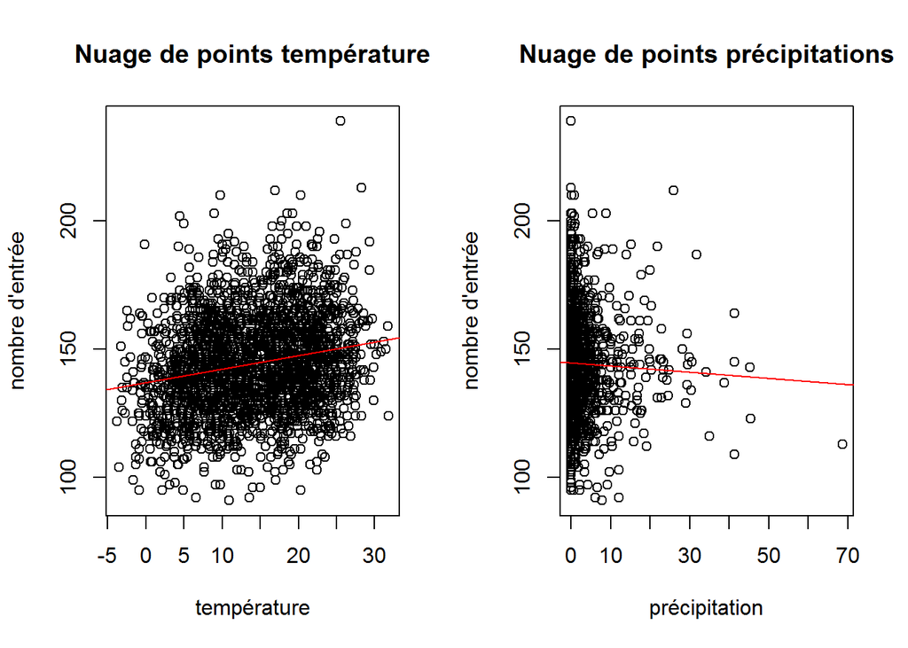

```r
par(mfrow=c(1,2))
plot(projet$temp,projet$entree,xlab="température",ylab="nombre d'entrée",main="Nuage de points température")
abline(lm(entree~temp,data=projet),lty=1,col="red")
plot(projet$precip,projet$entree,xlab="précipitation",ylab="nombre d'entrée",main="Nuage de points précipitations")
abline(lm(entree~precip,data=projet),lty=1,col="red")
```

```r
cor.test(projet$entree,projet$temp)
```

```
##
##  Pearson's product-moment correlation
##
## data:  projet$entree and projet$temp
## t = 10.361, df = 2489, p-value < 2.2e-16
## alternative hypothesis: true correlation is not equal to 0
## 95 percent confidence interval:
##  0.1653767 0.2406811
## sample estimates:
##       cor
## 0.2033296
```

D’après le test de corrélation, j’ai ici *p* inférieure au seuil de 5%. On peut donc rejeter l’hypothèse nulle (pas de corrélation). Il y a donc un lien linéaire significatif entre le nombre d’entrée et la température.

```r
cor.test(projet$entree,projet$precip)
```

```
##
##  Pearson's product-moment correlation
##
## data:  projet$entree and projet$precip
## t = -1.4456, df = 2489, p-value = 0.1484
## alternative hypothesis: true correlation is not equal to 0
## 95 percent confidence interval:
##  -0.06815892  0.01032227
## sample estimates:
##         cor
## -0.02896296
```

## 3.3 Boite à moustache // (1 pt)

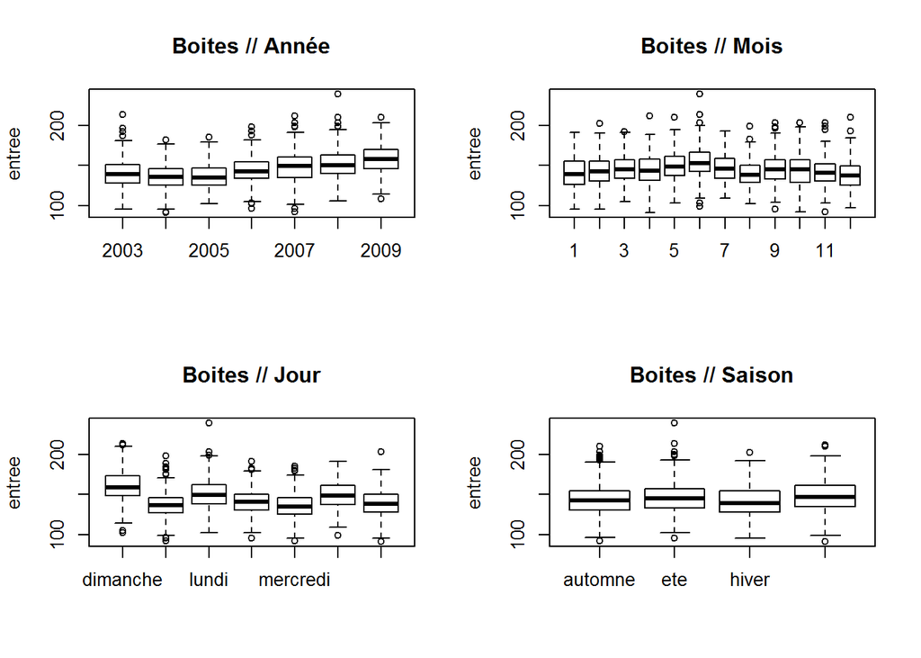

```r
par(mfrow=(c(2,2)))
boxplot(entree~annee,data=projet,main="Boites // Année",ylab="entree" )
boxplot(entree~mois,data=projet,main="Boites // Mois",ylab="entree" )
boxplot(entree~jour_semaine,data=projet,main="Boites // Jour",ylab="entree" )
boxplot(entree~saison,data=projet,main="Boites // Saison",ylab="entree" )
```

J’utilise ici le test de Kruskall-Wallis afin de vérifier s’il y a des différences significatives de moyenne entre les groupes

```r
kruskal.test(projet$entree~projet$annee)
```

```
##
##  Kruskal-Wallis rank sum test
##
## data:  projet$entree by projet$annee
## Kruskal-Wallis chi-squared = 398.26, df = 6, p-value < 2.2e-16
```

```r
kruskal.test(projet$entree~projet$mois)
```

```
##
##  Kruskal-Wallis rank sum test
##
## data:  projet$entree by projet$mois
## Kruskal-Wallis chi-squared = 136.48, df = 11, p-value < 2.2e-16
```

```r
kruskal.test(projet$entree~as.factor(projet$jour_semaine))
```

```
##
##  Kruskal-Wallis rank sum test
##
## data:  projet$entree by as.factor(projet$jour_semaine)
## Kruskal-Wallis chi-squared = 451.47, df = 6, p-value < 2.2e-16
```

```r
kruskal.test(projet$entree~as.factor(projet$saison))
```

```
##
##  Kruskal-Wallis rank sum test
##
## data:  projet$entree by as.factor(projet$saison)
## Kruskal-Wallis chi-squared = 59.173, df = 3, p-value = 8.831e-13
```

Ici, *p* est toujours inférieure au seuil de 5%. Il y a donc une différence significative de moyenne entre les groupes dans les quatres cas.

# 4 Représentation de la série agrégée par mois (3 pts)

Création d’un dataframe projet_agg

```r
projet_agg=data.frame(aaaa_mm=character(),entree=numeric(),temp=numeric(),precip=numeric(),stringsAsFactors = FALSE)
```

Utilisation d’une boucle for pour placer les valeurs des moyennes mois/annee dans projet_agg

```r
i=1
for (a in seq(2003,2009)) {
    for (m in seq(1,12)){
      projet_agg[i,1]=paste(a,sprintf("%02d",m),sep="-")
      projet_agg[i,2]=mean(projet$entree[projet$annee==a&projet$mois==m])
      projet_agg[i,3]=mean(projet$temp[projet$annee==a&projet$mois==m])
      projet_agg[i,4]=mean(projet$precip[projet$annee==a&projet$mois==m])
      i=i+1
    }
}
```

Suppression des deux dernieres lignes correspondantes au 11/2009 et 12/2009

```r
projet_agg=projet_agg[-c(83,84),]
```

Afin de tracer le 1er graphique, je dois faire quelques changements au dataframe projet_agg.  
J’appelerai mon nouveau dataframe projet_agg2. Les changements apportés sont: *suppression de la dernière ligne contenant une valeur manquante au niveau de la variable entree* changement de la variable aaaa_mm en date *ajout des variables annee et moi

```r
projet_agg2=projet_agg[-c(82),]
projet_agg2$aaaa_mm=as.Date(paste(projet_agg2$aaaa_mm,01,sep="-"),format="%Y-%m-%d")
projet_agg2$annee=substr(as.character(projet_agg2$aaaa_mm),1,4)
projet_agg2$annee=as.integer(projet_agg2$annee)
projet_agg2$mois=substr(as.character(projet_agg2$aaaa_mm),6,7)
projet_agg2$mois=as.integer(projet_agg2$mois)
```

Maintenant que ces changements sont faits, je peux afficher le graphique.  
Pour cela j’utiliserai une boucle for qui me permettra d’afficher les données année après année grâce aux fonctions lines() et points().  
Ensuite j’utiliserai la fonction points() pour marquer la moyenne de l’année et enfin la fonction segments pour faire un segment dont la longueur est égale à l’écart type.

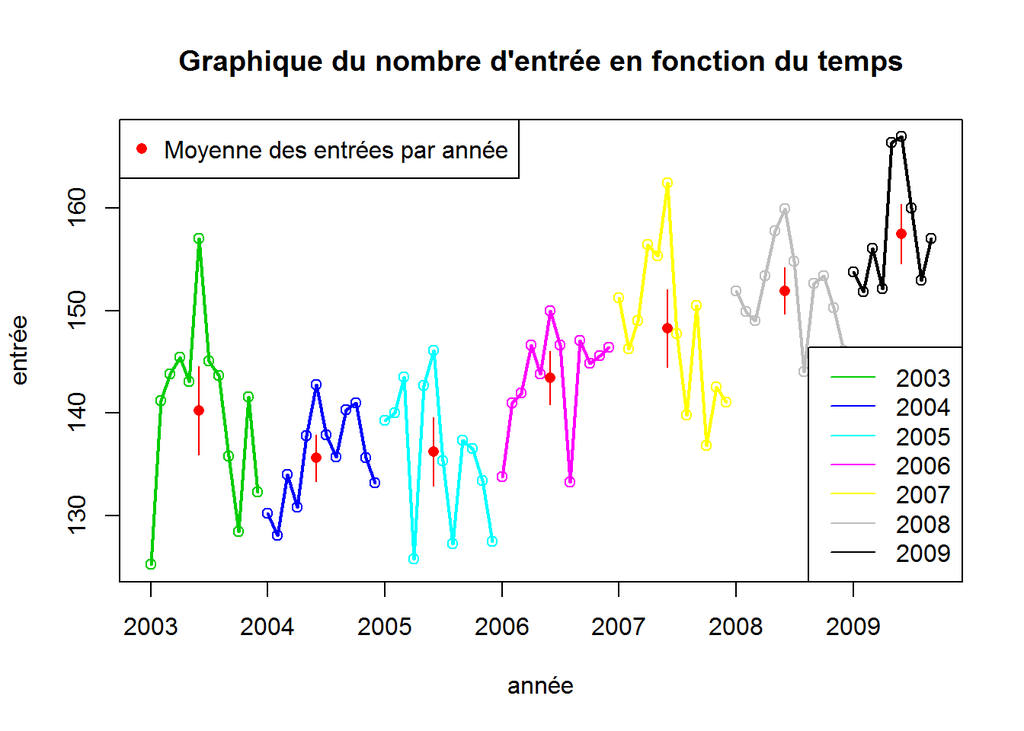

```r
plot(x=projet_agg2$aaaa_mm,y=projet_agg2$entree,type="n",xlab="année",ylab="entrée",main="Graphique du nombre d'entrée en fonction du temps")

for (i in seq(2003,2009)) {
lines(x=projet_agg2$aaaa_mm[projet_agg2$annee==i],y=projet_agg2$entree[projet_agg2$annee==i],col=i,lwd=2)
points(x=projet_agg2$aaaa_mm[projet_agg2$annee==i],y=projet_agg2$entree[projet_agg2$annee==i],col=i)
points(x=projet_agg2$aaaa_mm[projet_agg2$annee==i&projet_agg2$mois==6],y=mean(projet_agg2$entree[projet_agg2$annee==i]),col="red",pch=16)
segments(x0=projet_agg2$aaaa_mm[projet_agg2$annee==i&projet_agg2$mois==6], y0=mean(projet_agg2$entree[projet_agg2$annee==i])+sd(projet_agg2$entree[projet_agg2$annee==i])/2, x1=projet_agg2$aaaa_mm[projet_agg2$annee==i&projet_agg2$mois==6], y1=mean(projet_agg2$entree[projet_agg2$annee==i])-sd(projet_agg2$entree[projet_agg2$annee==i])/2,col = "red", lty = 1)
}
legend("topleft",legend="Moyenne des entrées par année",pch=16,col="red")
legend("bottomright",legend=c("2003","2004","2005","2006","2007","2008","2009"),lty=c(1,1,1,1,1,1,1),col=seq(2003,2009))
```

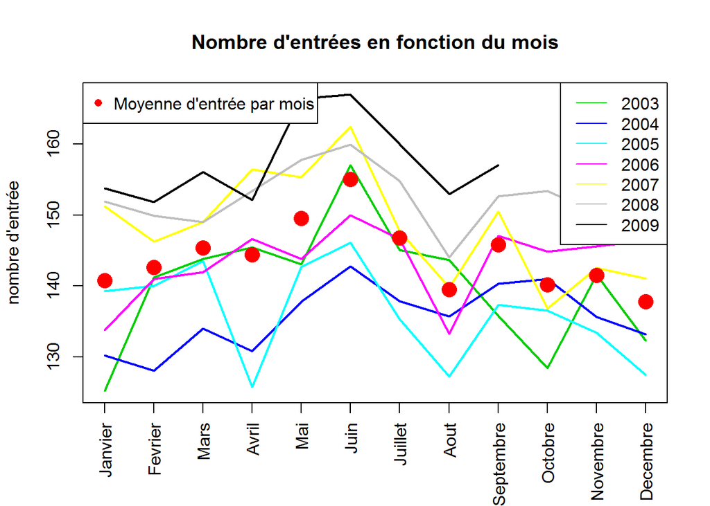

```
                .
```

```r
plot(projet_agg2$mois,projet_agg2$entree,type="n",xlab = "",ylab="nombre d'entrée",xaxt="none",main="Nombre d'entrées en fonction du mois")
axis(1, at=1:12, labels=c("Janvier","Fevrier","Mars","Avril","Mai","Juin","Juillet","Aout","Septembre","Octobre","Novembre","Decembre"), las=2,cex.axis=1)
for (i in seq(2003,2009)){
lines(projet_agg2$mois[projet_agg2$annee==i],projet_agg2$entree[projet_agg2$annee==i],type="l",col=i,lwd=2)
}
for (i in seq(1,12)){
points(x=i,y=mean(projet_agg2$entree[projet_agg2$mois==i]),pch=16,col="red",cex=2)
}
legend("topleft", pch=16, col="red",legend="Moyenne d'entrée par mois",text.font=1,text.width = 4)
legend("topright",legend=c("2003","2004","2005","2006","2007","2008","2009"),lty=c(1,1,1,1,1,1,1),col=seq(2003,2009))
```

Afin de créer ce second graphe, j’ai gardé mon dataframe projet_agg2. La fonction axis() m’a surtout permis de renommer les étiquettes de l’abcisse.

On remarquera une tendence haussière à partir de 2004 jusqu’en 2009 au niveau des nombres d’entrées aux urgences. Concernant la saisonalité, il semblerait que le printemps soit propice aux visites chez les urgences avec un pic en Juin.

# 5 Lissage par moyenne mobile (3 pts)

## 5.2 Fonction lissage()

```r
lissage=function(var_to_smooth,alpha,var_time=seq(1,length(var_to_smooth))) {

  stopifnot(is.numeric(var_to_smooth),is.numeric(alpha),length(alpha)==1,alpha>1&alpha<(length(var_to_smooth)/4),length(var_time)==length(var_to_smooth),class(var_time)=="Date")

  valeurs_lissees=c()
  time_to_estimate=c()

  for (i in seq(1,length(var_to_smooth))) {

    if(i-alpha>0&i+alpha<=length(var_to_smooth)) {

      valeurs_lissees[i]=(1/(2*alpha+1))*sum(var_to_smooth[(i-alpha):(i+alpha)])
      time_to_estimate[i]=as.character(var_time[i])
    } else {
      valeurs_lissees[i]=NA
      time_to_estimate[i]=NA
    }

  }
  valeurs_lissees=valeurs_lissees[!is.na(valeurs_lissees)]
  time_to_estimate=time_to_estimate[!is.na(time_to_estimate)]
  return(list(valeurs_lissees,time_to_estimate))
}
```

Création d’un dataframe projet2 sans les valeurs manquantes de la variable entree du dataframe projet et appel de la fonction lissage() avec alpha valant 10,50 et 200.

```r
projet2=projet[-c(2492:2496),]
l10=lissage(projet2$entree,10,projet2$date_j)
l50=lissage(projet2$entree,50,projet2$date_j)
l200=lissage(projet2$entree,200,projet2$date_j)
```

Conversion du vecteur time_to_estimate des listes l10, l50 et l200 en date.

```r
l10[[2]]=as.Date(l10[[2]],format="%Y-%m-%d")
l50[[2]]=as.Date(l50[[2]],format="%Y-%m-%d")
l200[[2]]=as.Date(l200[[2]],format="%Y-%m-%d")
```

Affichage du graphique

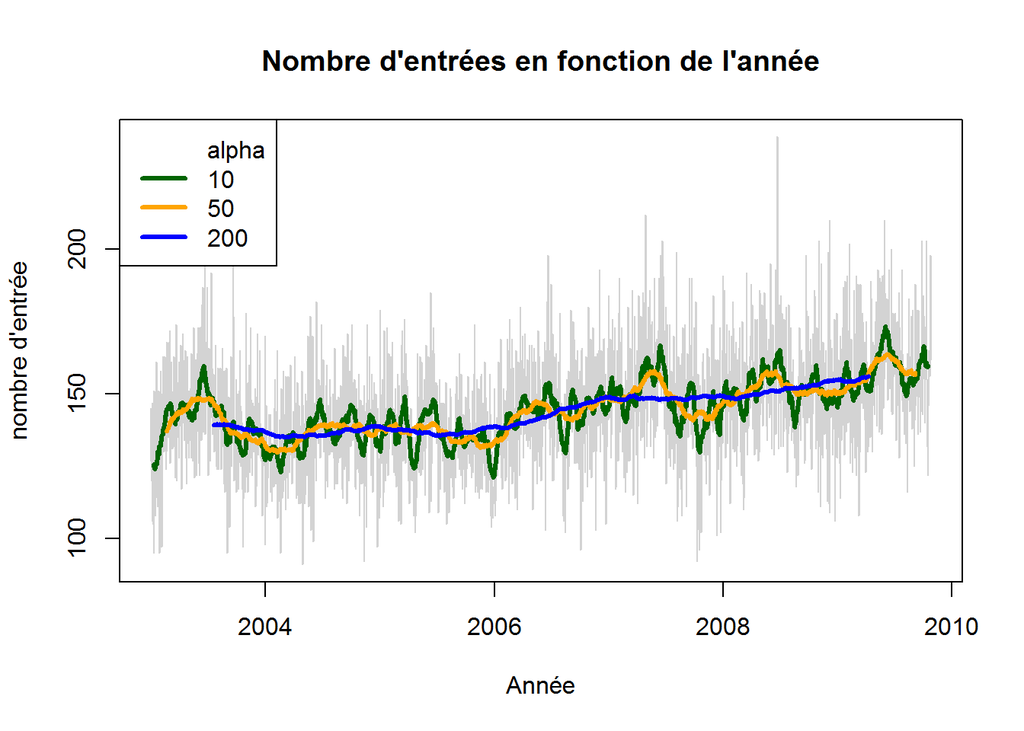

```r
plot(projet2$date_j,projet2$entree,type="l",col="lightgrey",xlab = "Année",ylab="nombre d'entrée",main="Nombre d'entrées en fonction de l'année")
lines(l10[[2]],l10[[1]],type="l",lwd=3,col="darkgreen")
lines(l50[[2]],l50[[1]],type="l",lwd=3,col="orange")
lines(l200[[2]],l200[[1]],lwd=3,type="l",col="blue")
legend("topleft",legend=c("alpha","10","50","200"),col=c("0","darkgreen","orange","blue"),lty=c(0,1,1,1),lwd=c(0,3,3,3))
```

.  
On remarque donc que plus alpha augmente et plus la courbe est lisse.

# 6 Régression linéaire

Création de la fonction reg_lin()

```r
reg_lin=function(x,y) {

  stopifnot(is.vector(y),nrow(x)==length(y))
  hat_beta=c()
  hat_beta=(solve(crossprod(x))%*%crossprod(x,y))
  residuals=(y-x%*%hat_beta)
  s2=(1/(nrow(x)-ncol(x)))*sum(residuals[1:2491]^2)

  return(list(hat_beta,s2,residuals))
}
```

Création des variables lundi à samedi et création de la matrice x à partir du dataframe projet2 qui est le dataframe projet sans les valeurs manquantes d’entrees

```r
lundi=as.integer(projet2$jour_semaine=="lundi")
mardi=as.integer(projet2$jour_semaine=="mardi")
mercredi=as.integer(projet2$jour_semaine=="mercredi")
jeudi=as.integer(projet2$jour_semaine=="jeudi")
vendredi=as.integer(projet2$jour_semaine=="vendredi")
samedi=as.integer(projet2$jour_semaine=="samedi")
x=matrix(c(rep(1,2491),projet2$precip,projet2$temp,lundi,mardi,mercredi,jeudi,vendredi,samedi),byrow=FALSE,ncol=9)
```

Application de la fonction reg_lin() à la matrice x

```r
result=reg_lin(x,projet2$entree)
```

Creation d’une matrice m2 contenant toutes les observations du dataframe projet

```r
lundi=as.integer(projet$jour_semaine=="lundi")
mardi=as.integer(projet$jour_semaine=="mardi")
mercredi=as.integer(projet$jour_semaine=="mercredi")
jeudi=as.integer(projet$jour_semaine=="jeudi")
vendredi=as.integer(projet$jour_semaine=="vendredi")
samedi=as.integer(projet$jour_semaine=="samedi")
x2=matrix(c(rep(1,2496),projet$precip,projet$temp,lundi,mardi,mercredi,jeudi,vendredi,samedi),byrow=FALSE,ncol=9)
```

Prediction des 5 valeurs manquantes

```r
prediction=x2[2492:2496,]%*%result[[1]]
```

Affichage du graphique

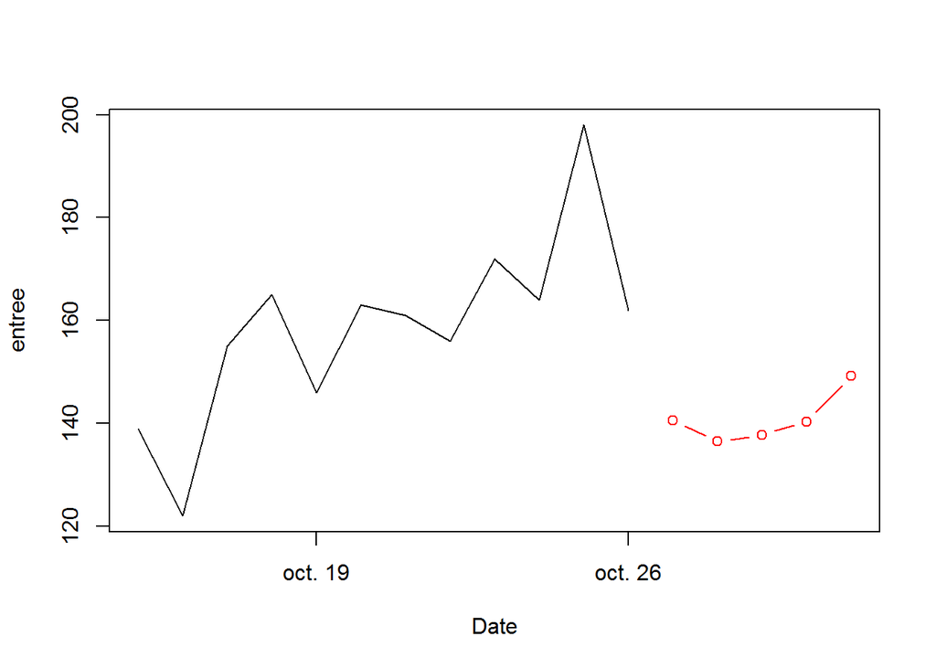

```r
plot(projet$date_j[2480:2496],projet$entree[2480:2496],type="l",xlab="Date",ylab="entree")
lines(projet$date_j[2492:2496],prediction,type="b",col="red")
```

# Conclusion

Prévoir le nombre d’entrées selon plusieurs facteurs tels que le jour de la semaine, la saison et la météo et un atout indéniable pour le secteur hospitalier et son organisation. Notre modèle de régression linéaire a encore une marge d’amélioration conséquente s’il était possible d’obtenir des données encore plus complètes des ervices d’urgences.